# **Panorama da inflação**

Os principais índices de inflação do Brasil, apontam em agosto de 2000 um avanço da inflação de em média **1.64%**. Com esse resultado, no ano a inflação acumula uma variação média positiva de **4.80%**, e em 12 meses uma variação média acumulada de **10.07%**.

[output not shown]

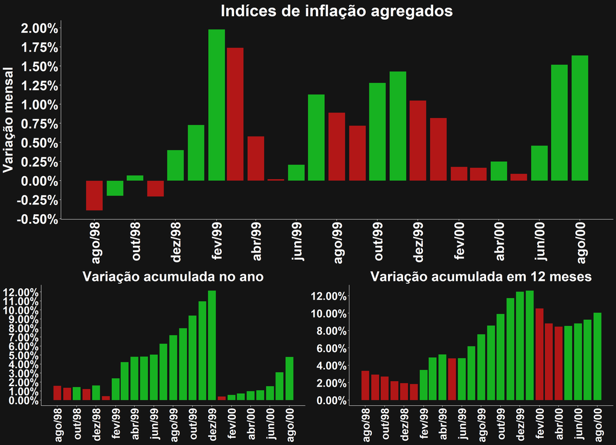

Índices selecionados para a média: IPCA, INPC e IGP-M.

# IPCA

O Indíce de Preços ao Consumidor Amplo (IPCA) variou 1.31% em agosto, valor superior ao mesmo período do ano anterior quando apresentou uma taxa de 0.56%. Com esse resultado o indíce acumula no ano uma variação positiva de 4.63%, e em 12 meses uma variação positiva de 7.86%.

|  | 08/1999 | 07/2000 | 08/2000 |
| --- | --- | --- | --- |
| Variação mensal | 0.56% | 1.61% | 1.31% |
| Variação acumulada no ano | 5.68% | 3.28% | 4.63% |
| Variação acumulada em 12 meses | 5.69% | 7.06% | 7.86% |

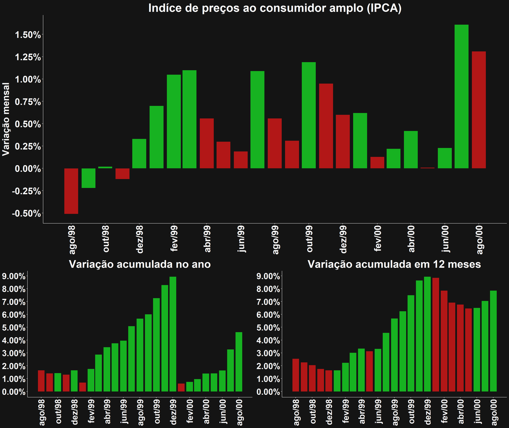

|  | Variação mensal | Variação acumulada no ano | Peso mensal |
| --- | --- | --- | --- |
| Alimentação e bebidas | 2.07% | 3.06% | 22.11% |
| Habitação | 0.43% | 2.53% | 15.83% |
| Artigos de residência | 0.82% | 3.05% | 5.82% |
| Vestuário | 0.42% | 1.28% | 5.49% |
| Transportes | 2.7% | 9.12% | 21.4% |
| Saúde e cuidados pessoais | 0.89% | 3.03% | 11.21% |
| Despesas pessoais | 0.32% | 4.69% | 9.68% |
| Educação | 0.2% | 3.97% | 4.87% |
| Comunicação | -0.04% | 12.46% | 3.57% |

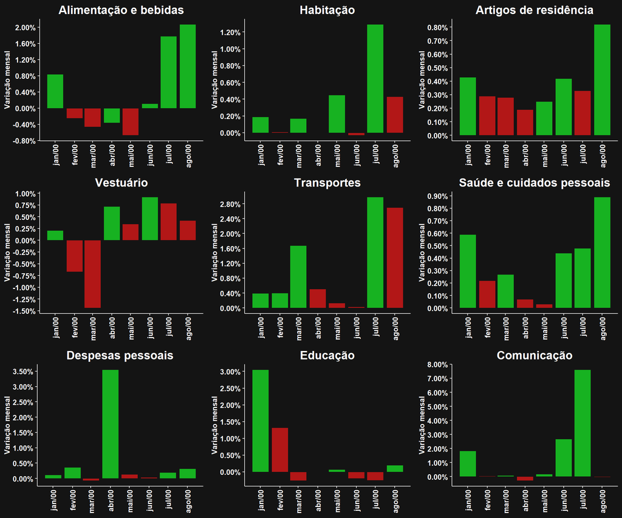

A nível de sub-itens os que mais influenciaram positivamente no resultado em relação ao seu peso foram Gasolina (7.54%%) e Etanol (16.7%%), e negativamente Cebola (-21.06%%) e Hotel (-2.95%%).

|  | Variação mensal | Variação acumulada no ano | Peso mensal |
| --- | --- | --- | --- |
| Gasolina | 7.54% | 20.64% | 3.88% |
| Plano de saúde | 3.65% | 5.42% | 2.6% |
| Etanol | 16.7% | 28.46% | 0.98% |
| Frango | 15.36% | -1.75% | 0.74% |

|  | Variação mensal | Variação acumulada no ano | Peso mensal |
| --- | --- | --- | --- |
| Aluguel residencial | -0.13% | -1.93% | 5.36% |
| Calça comprida masculina | -1.43% | -1.17% | 0.4% |
| Hotel | -2.95% | 3.39% | 0.29% |
| Cebola | -21.06% | 46.53% | 0.06% |

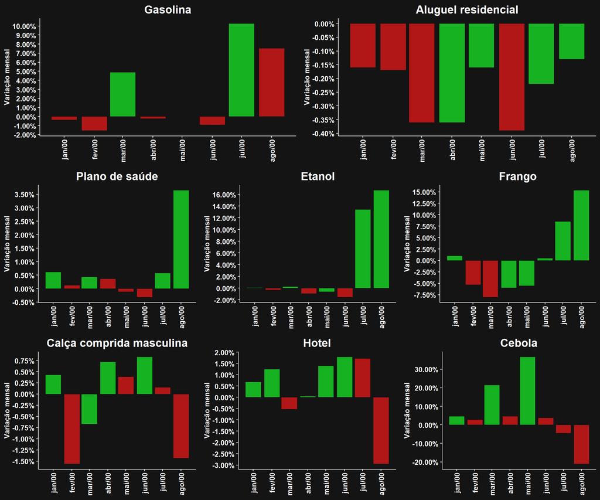

# INPC

O Indíce Nacional de Preços ao Consumidor (INPC) variou 1.21% em agosto, valor superior ao mesmo período do ano anterior quando apresentou uma taxa de 0.55%. Com esse resultado o indíce acumula no ano uma variação positiva de 3.78%, e em 12 meses uma variação positiva de 6.96%.

|  | 08/1999 | 07/2000 | 08/2000 |
| --- | --- | --- | --- |
| Variação mensal | 0.55% | 1.39% | 1.21% |
| Variação acumulada no ano | 5.21% | 2.54% | 3.78% |
| Variação acumulada em 12 meses | 5.25% | 6.26% | 6.96% |

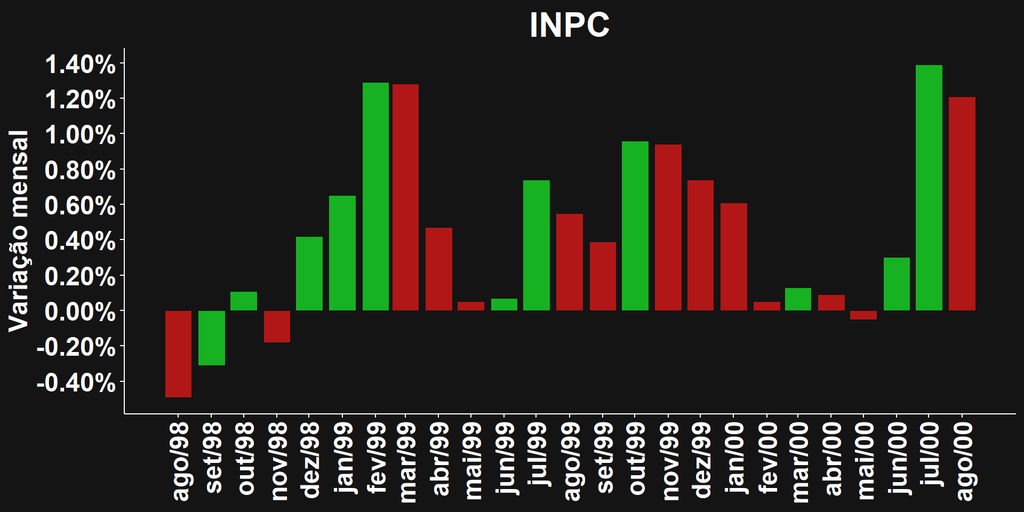

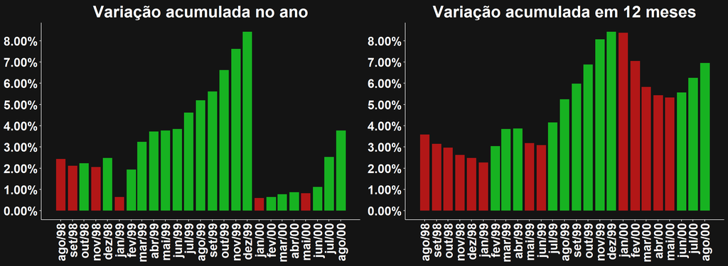

# IGP-M

O Indíce Geral de Preços de Mercado (IGP-M) variou 2.39% em agosto, valor superior ao mesmo período do ano anterior quando apresentou uma taxa de 1.56%. Com esse resultado o indíce acumula no ano uma variação positiva de 5.98%, e em 12 meses uma variação positiva de 15.39%.

|  | 08/1999 | 07/2000 | 08/2000 |
| --- | --- | --- | --- |
| Variação mensal | 1.56% | 1.57% | 2.39% |
| Variação acumulada no ano | 10.75% | 3.51% | 5.98% |
| Variação acumulada em 12 meses | 11.81% | 14.46% | 15.39% |

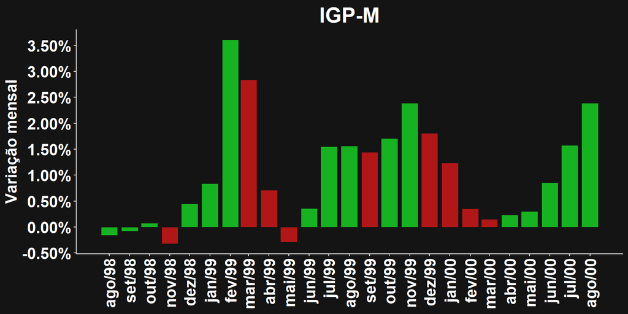

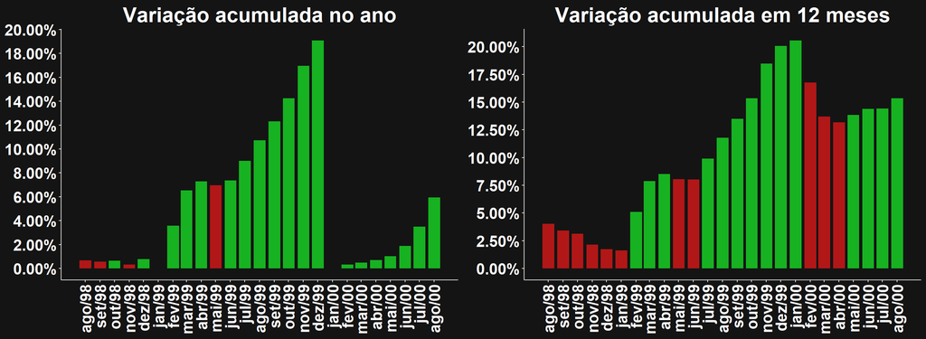

# IGP-DI

O Indíce Geral de Preços - Disponibilidade Interna (IGP-DI) variou 1.82% em agosto, valor superior ao mesmo período do ano anterior quando apresentou uma taxa de 1.45%. Com esse resultado o indíce acumula no ano uma variação positiva de 6.33%, e em 12 meses uma variação positiva de 15.27%.

|  | 08/1999 | 07/2000 | 08/2000 |
| --- | --- | --- | --- |
| Variação mensal | 1.45% | 2.26% | 1.82% |
| Variação acumulada no ano | 10.54% | 4.43% | 6.33% |
| Variação acumulada em 12 meses | 12.64% | 14.85% | 15.27% |

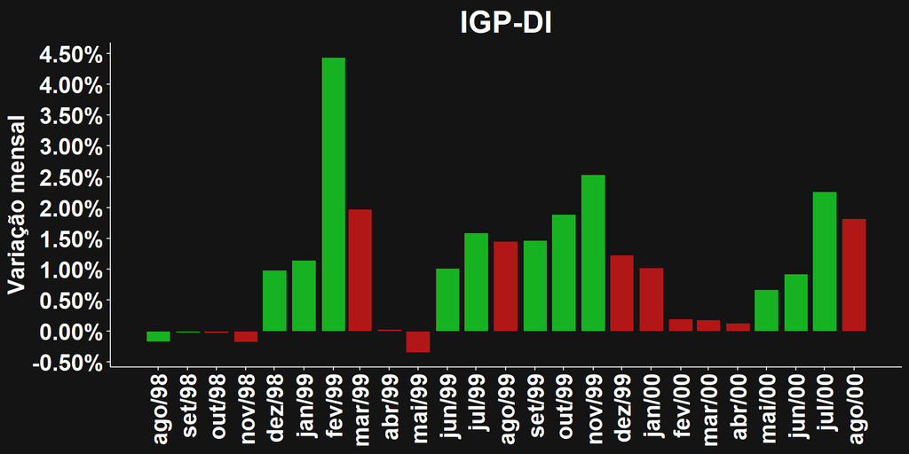

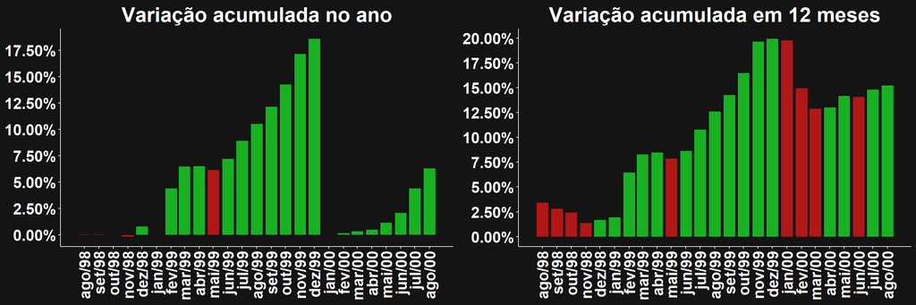

[output not shown]

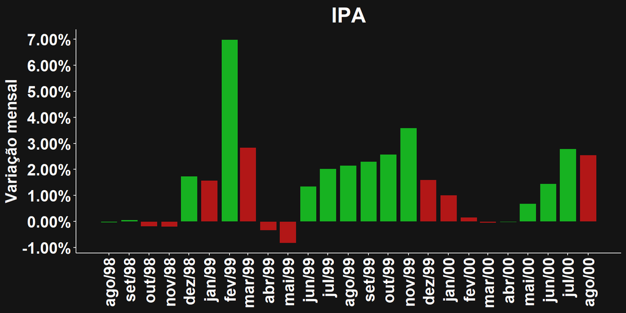

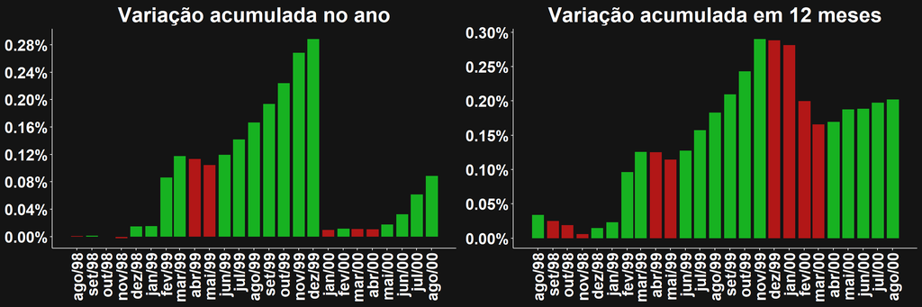

O Indíce de Preços ao Consumidor (IPC), integrante do IGP-DI com peso de 30%, apresentou variação de 0.86% em agosto, valor superior ao mesmo período do ano anterior quando apresentou uma taxa de 0.48%. Com esse resultado o indíce acumula no ano uma variação positiva de 4.02%, e em 12 meses uma variação positiva de 8.07%.

|  | 08/1999 | 07/2000 | 08/2000 |
| --- | --- | --- | --- |
| Variação mensal | 0.48% | 1.91% | 0.86% |
| Variação acumulada no ano | 5.41% | 3.14% | 4.02% |
| Variação acumulada em 12 meses | 6% | 7.67% | 8.07% |

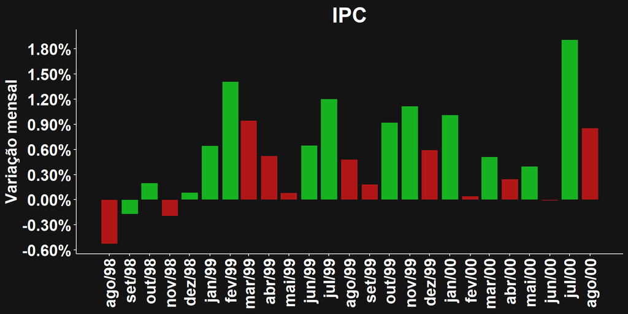

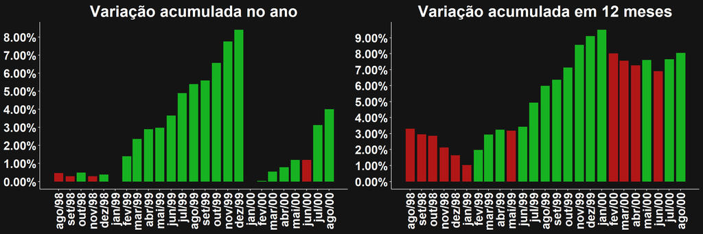

|  | 08/1999 | 07/2000 | 08/2000 |
| --- | --- | --- | --- |
| Variação mensal | 0.69% | 0.3% | 0.39% |
| Variação acumulada no ano | 4.55% | 4.38% | 4.79% |
| Variação acumulada em 12 meses | 5.14% | 10.36% | 10.02% |

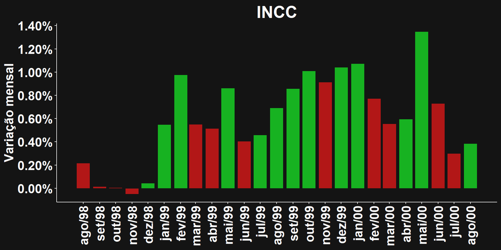

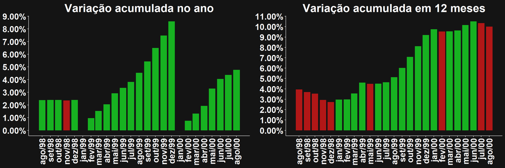

# Estatísticas

As estatísticas descritivas a seguir são feitas com base nos últimos 48 meses, e tem como objetivo possibilitar a avaliação do resultado observado em comparação aos períodos anteriores.

|  | Minimo | 1 Quartil | Mediana | Media | 3 Quartil | Maximo | Desvio Padrão |
| --- | --- | --- | --- | --- | --- | --- | --- |
| IPCA | -0.51% | 0.18% | 0.38% | 0.44% | 0.6% | 1.61% | 0.43% |
| INPC | -0.49% | 0.11% | 0.38% | 0.41% | 0.66% | 1.39% | 0.42% |
| IGP-M | -0.32% | 0.17% | 0.44% | 0.75% | 1.17% | 3.61% | 0.85% |
| IGP-DI | -0.38% | 0.13% | 0.59% | 0.75% | 1.15% | 4.44% | 0.9% |
| IPA | -0.82% | 0.04% | 0.47% | 0.95% | 1.59% | 6.99% | 1.36% |
| IPC | -0.52% | 0.16% | 0.43% | 0.48% | 0.69% | 1.91% | 0.54% |
| INCC | -0.5% | 0.26% | 0.53% | 0.53% | 0.86% | 1.35% | 0.38% |

Levando em consideração o desvio padrão de cada indíce, proporcionalmente os que mais se afastaram da média foram o IPCA, o IGP-M e o INPC.

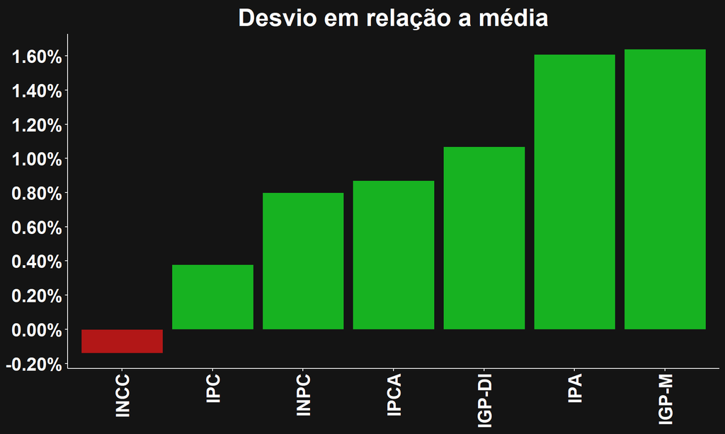

**João Victor Gomes**  
**jvg.santana@gmail.com**  
**[linkedin.com/in/jvictorgomes](https://www.linkedin.com/in/jvictorgomes/)**